# Income Inequality vs Index of Health and Social Problmes

coop711

2015년 5월 3일

## Data Preparation

`xlsx` package은 Excel 자료를 다루는 데 매우 유용한데, `read.xlsx(filename, n)`의 구조로 되어 있으며, 여기서 `n`은 엑셀 시트의 번호이다.

```r
install.packages("xlsx", repos="http://cran.rstudio.com")
library(xlsx)
```

Equality Trust에서 기부금을 받고 제공하는 두 종류의 자료 중 23개 국가의 각종 지표를 비교한 것을 읽어들이면,

```r
data.full<-read.xlsx("international-inequality.xls", 1)
str(data.full)
```

```
## 'data.frame':    23 obs. of  29 variables:
##  $ Country                          : chr  "Australia" "Austria" "Belgium" "Canada" ...
##  $ Income.inequality                : num  7 4.82 4.6 5.62 4.3 ...
##  $ Trust                            : num  39.9 33.9 30.7 38.8 66.5 ...
##  $ Life.expectancy                  : num  79.2 78.5 78.8 79.3 76.6 ...
##  $ Infant.mortality                 : num  4.9 4.8 5 5.3 5.3 3.7 4.4 4.4 5 5.9 ...
##  $ Obesity                          : num  18.4 14.5 13.5 12.8 15 ...
##  $ Mental.illness                   : num  23 NA 12 19.9 NA ...
##  $ Maths.and.literacy.scores        : num  524 498 518 530 503 ...
##  $ Teenage.births                   : num  18.4 14 9.9 20.2 8.1 ...
##  $ Homicides                        : num  16.9 11.6 13 17.3 12.7 ...
##  $ Imprisonment..log.               : num  4.61 4.52 4.28 4.77 4.17 ...
##  $ Social.mobility                  : num  NA NA NA 0.143 0.143 ...
##  $ Index.of.health...social_problems: num  0.0652 0.01 -0.2333 -0.0707 -0.1883 ...
##  $ Child.overweight                 : num  NA 11.9 10.4 19.5 10.3 ...
##  $ Drugs.index                      : num  1.7074 -0.0182 -0.1778 0.6068 -0.0948 ...
##  $ Calorie.intake                   : num  3142 3753 3632 3167 3405 ...
##  $ Public.health.expenditure        : num  67.9 69.3 71.7 70.8 82.4 75.6 76 74.9 56 76 ...
##  $ Child.wellbeing                  : num  -0.2147 -0.0679 0.047 0.0395 0.214 ...
##  $ Maths.education.science.score    : num  525 496 515 526 494 ...
##  $ Child.conflict                   : num  NA 0.309 0.329 0.237 -0.137 ...
##  $ Foreign.aid                      : num  0.25 0.52 0.53 0.34 0.81 ...
##  $ Recycling                        : num  7.4 NA NA NA NA ...
##  $ Peace.index                      : num  1.66 1.48 1.49 1.48 1.38 ...
##  $ Maternity.leave                  : num  0 16 15 17 18 18 16 14 17 18 ...
##  $ Advertising                      : num  1.24 0.97 0.82 0.77 0.75 ...
##  $ Police                           : num  304 305 357 186 192 160 NA 303 NA NA ...
##  $ Social.expenditure               : num  17.8 27.5 26.5 17.2 27.6 25.8 29 27.3 19.9 15.8 ...
##  $ Women.s_status                   : num  0.457 -0.808 0.606 0.563 0.827 ...
##  $ Lone.parents                     : num  21 15 12 17 22 19 12 21 3 14 ...
```

이 자료 중 소득불평등을 나타내는 지표는 5분위계수로서 두번째 컬럼에 `Income.inequality`라는 이름으로 나와 있고, 건강과 사회문제 지표는 13번째 컬럼에 `Index.of.health...social_problems`라는 이름으로 주어져 있다. 나라들은 `Country`라는 변수명으로 첫번째 컬럼에 나와 있다. 그리고, 건강과 사회문제 지표에 결측치들이 있기 때문에 먼저 이 나라들을 제외하고 분석작업을 수행하여야 한다.

```r
which(is.na(data.full$Index.of.health...social_problems))
```

```
## [1] 11 18
```

결측치가 있는 나라를 빼고, 필요한 변수만 챙겨서 새로운 data frame 을 구성하기 위하여 건강과 사회문제 지표의 위치를 찾아보자.

```r
names(data.full)
```

```
##  [1] "Country"
##  [2] "Income.inequality"
##  [3] "Trust"
##  [4] "Life.expectancy"
##  [5] "Infant.mortality"
##  [6] "Obesity"
##  [7] "Mental.illness"
##  [8] "Maths.and.literacy.scores"
##  [9] "Teenage.births"
## [10] "Homicides"
## [11] "Imprisonment..log."
## [12] "Social.mobility"
## [13] "Index.of.health...social_problems"
## [14] "Child.overweight"
## [15] "Drugs.index"
## [16] "Calorie.intake"
## [17] "Public.health.expenditure"
## [18] "Child.wellbeing"
## [19] "Maths.education.science.score"
## [20] "Child.conflict"
## [21] "Foreign.aid"
## [22] "Recycling"
## [23] "Peace.index"
## [24] "Maternity.leave"
## [25] "Advertising"
## [26] "Police"
## [27] "Social.expenditure"
## [28] "Women.s_status"
## [29] "Lone.parents"
```

```r
which(names(data.full)=="Index.of.health...social_problems")
```

```
## [1] 13
```

새로운 data frame 을 `data.1` 으로 저장하자. 시각적 가독성을 높이기 위하여 자릿수를 조정한다.

```r
options(digits=2)
data.1<-data.full[-c(11, 18), c(1, 2, 13)]
data.1
```

```
##        Country Income.inequality Index.of.health...social_problems
## 1    Australia               7.0                             0.065
## 2      Austria               4.8                             0.010
## 3      Belgium               4.6                            -0.233
## 4       Canada               5.6                            -0.071
## 5      Denmark               4.3                            -0.188
## 6      Finland               3.7                            -0.433
## 7       France               5.6                             0.051
## 8      Germany               5.2                            -0.065
## 9       Greece               6.2                             0.380
## 10     Ireland               6.1                             0.254
## 12       Italy               6.7                            -0.116
## 13       Japan               3.4                            -1.256
## 14 Netherlands               5.3                            -0.510
## 15 New Zealand               6.8                             0.291
## 16      Norway               3.9                            -0.633
## 17    Portugal               8.0                             1.180
## 19       Spain               5.6                            -0.304
## 20      Sweden               4.0                            -0.834
## 21 Switzerland               5.7                            -0.455
## 22          UK               7.2                             0.789
## 23         USA               8.5                             2.021
```

## Plots

`plot` 과 기타 작업의 편의를 위하여 `data.1`을 검색 목록에 올린다.

```r
attach(data.1)
```

우선 소득불평등과 건강 및 사회문제 지표의 관계를 대략적으로 살펴보면,

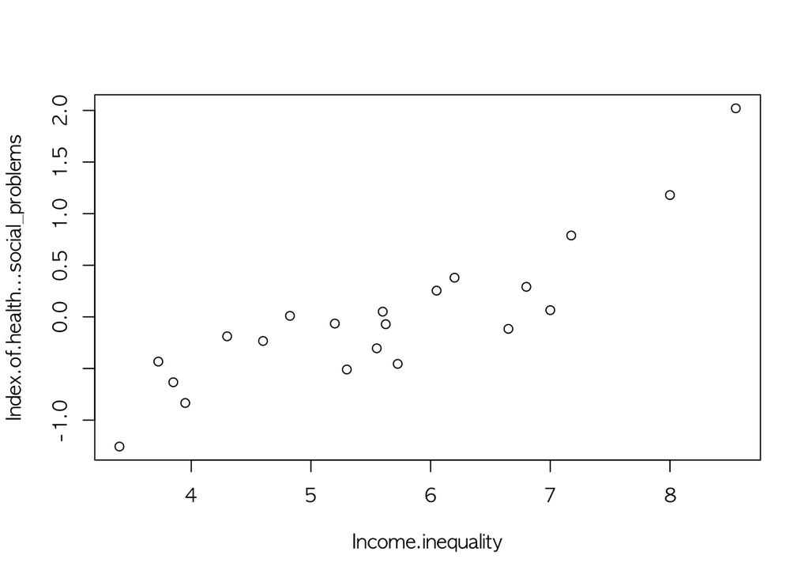

```r
plot(Index.of.health...social_problems~Income.inequality, data=data.1)
```

매우 높은 양의 상관관계(r = 0.87) 가 관찰됨을 알 수 있다.

각 점이 어느 나라를 나타내는지 표시하기 위하여 `text()` 를 활용하자. 동그라미 대신 까만 점으로 표시하고, 나라 이름을 올려보자.

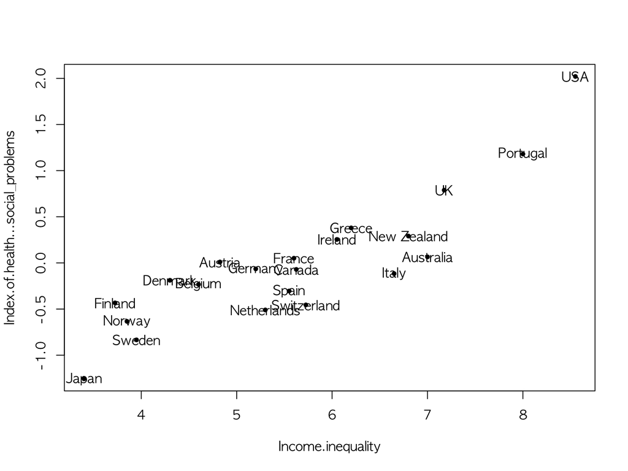

```r
plot(Index.of.health...social_problems~Income.inequality, data=data.1, pch=20)
text(Income.inequality, Index.of.health...social_problems, labels=Country)
```

text label의 위치 기본값은 바로 점 위임을 알 수 있다. 위치 선정에 가능한 값들을 넣어보자.

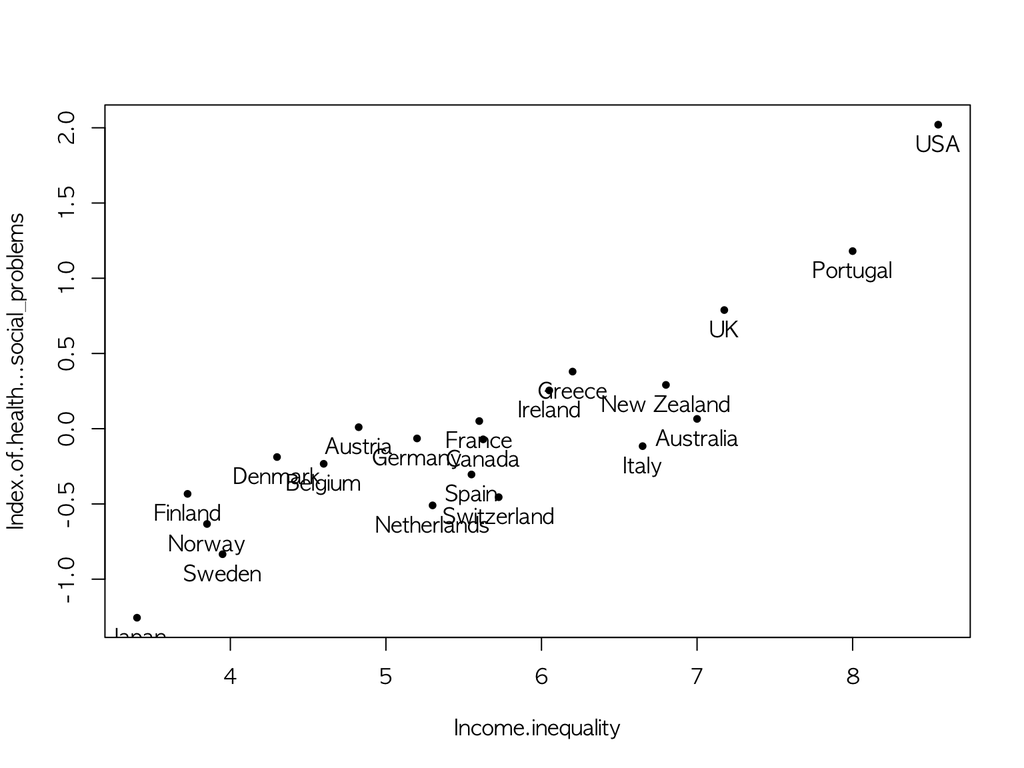

```r
plot(Index.of.health...social_problems~Income.inequality, data=data.1, pch=20)
text(Income.inequality, Index.of.health...social_problems, labels=Country, pos=1)
```

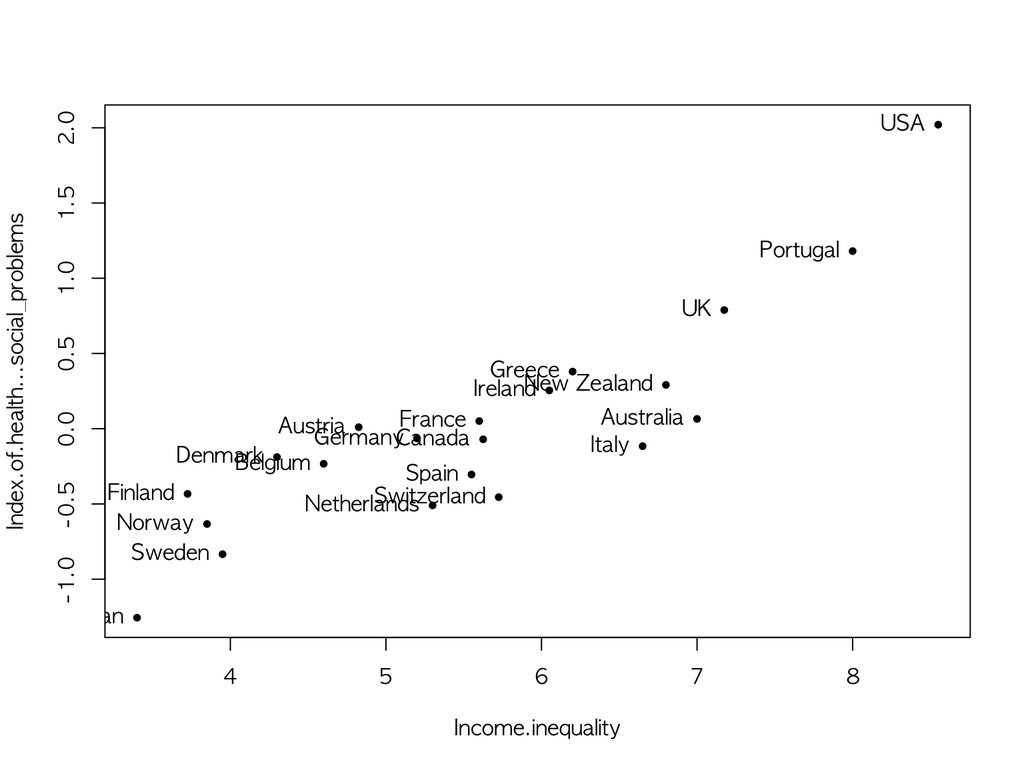

```r
plot(Index.of.health...social_problems~Income.inequality, data=data.1, pch=20)
text(Income.inequality, Index.of.health...social_problems, labels=Country, pos=2)
```

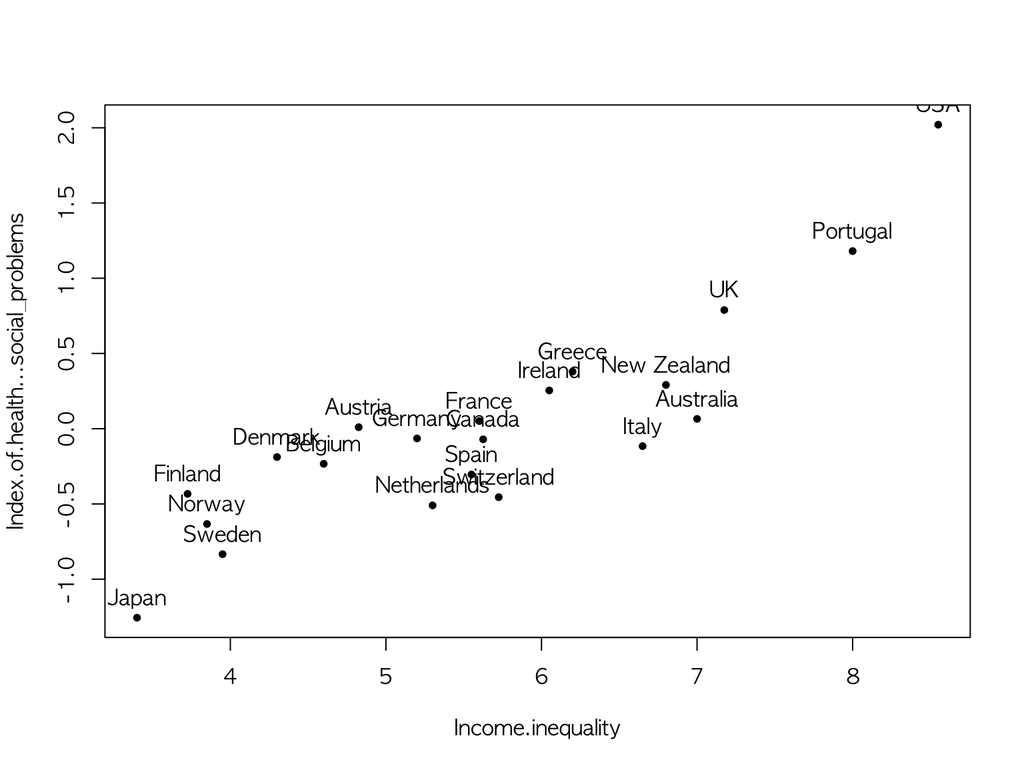

```r
plot(Index.of.health...social_problems~Income.inequality, data=data.1, pch=20)
text(Income.inequality, Index.of.health...social_problems, labels=Country, pos=3)
```

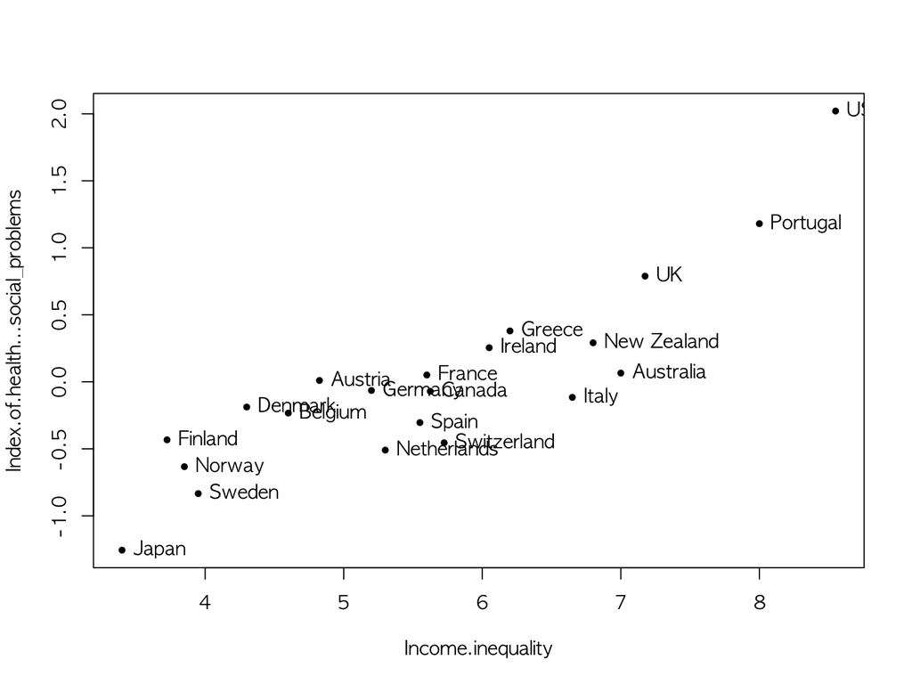

```r
plot(Index.of.health...social_problems~Income.inequality, data=data.1, pch=20)
text(Income.inequality, Index.of.health...social_problems, labels=Country, pos=4)
```

우선 x-축과 y-축의 범위를 `xlim=c(3, 9), ylim=c(-1.5, 2.5)`로 하여 미국과 일본의 라벨이 도표 밖으로 나가지 않게 하자. `pos=4`로 하고 `cex=0.8`로 하여 글자 크기를 줄여보면,

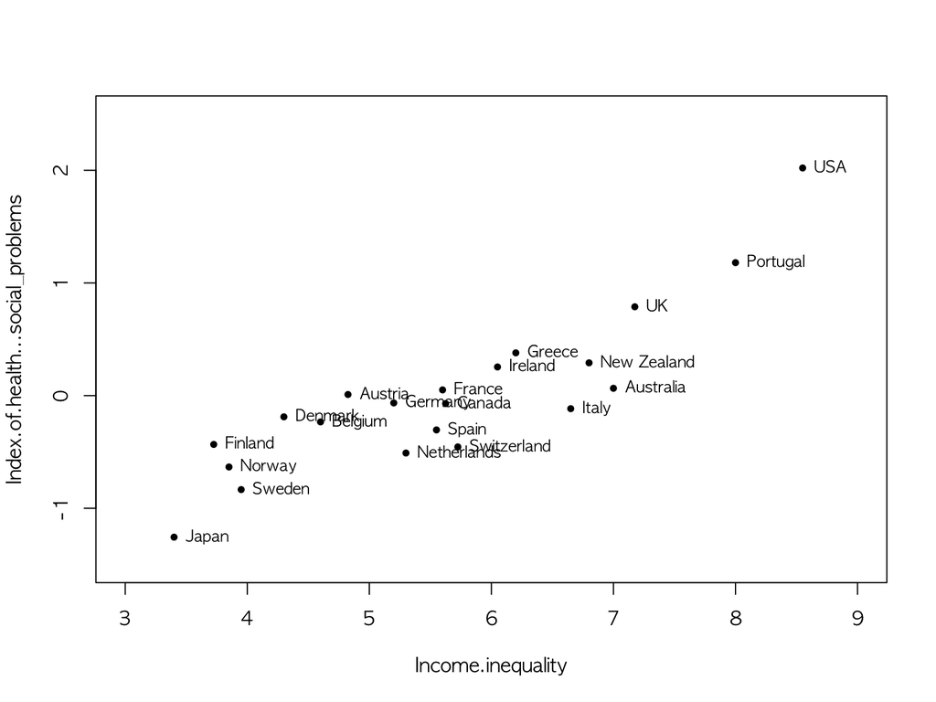

```r
plot(Index.of.health...social_problems~Income.inequality, data=data.1, pch=20, xlim=c(3, 9), ylim=c(-1.5, 2.5))
text(Income.inequality, Index.of.health...social_problems, labels=Country, pos=4, cex=0.8)
```

```r
which(Country %in% c("Austria", "Denmark", "Germany", "Netherlands"))
```

```
## [1]  2  5  8 13
```

```r
text.left<-which(Country %in% c("Austria", "Denmark", "Germany", "Netherlands"))
text.left
```

```
## [1]  2  5  8 13
```

```r
text.right<-(1:21)[-text.left]
text.right
```

```
##  [1]  1  3  4  6  7  9 10 11 12 14 15 16 17 18 19 20 21
```

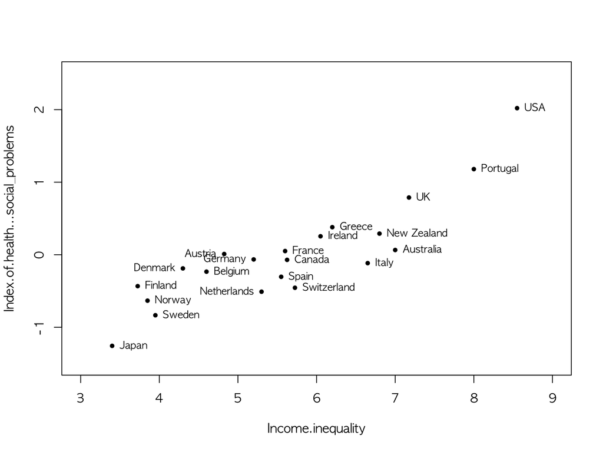

```r
plot(Index.of.health...social_problems~Income.inequality, data=data.1, pch=20, xlim=c(3, 9), ylim=c(-1.5, 2.5))
text(Income.inequality[text.right], Index.of.health...social_problems[text.right], labels=Country[text.right], pos=4, cex=0.8)
text(Income.inequality[text.left], Index.of.health...social_problems[text.left], labels=Country[text.left], pos=2, cex=0.8)
```

독일의 라벨을 위로 붙이면 보기가 나아질 것으로 생각되므로,

```r
which(Country == "Germany")
```

```
## [1] 8
```

```r
text.up<-which(Country == "Germany")
text.up
```

```
## [1] 8
```

```r
which(text.left==text.up)
```

```
## [1] 3
```

```r
text.left<-text.left[!(text.left == text.up)]
text.left
```

```
## [1]  2  5 13
```

이제 조정된 text 외에 x-축과 y-축에 적절한 라벨과 메인 타이틀을 넣어보자.

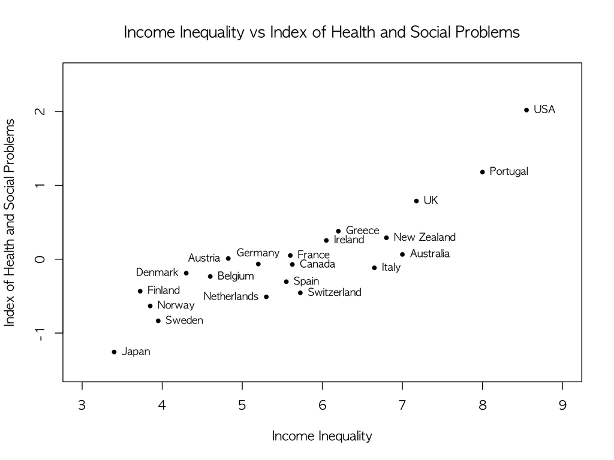

```r
plot(Index.of.health...social_problems~Income.inequality, data=data.1, pch=20, xlim=c(3, 9), ylim=c(-1.5, 2.5), ann=FALSE)
text(Income.inequality[text.right], Index.of.health...social_problems[text.right], labels=Country[text.right], pos=4, cex=0.8)
text(Income.inequality[text.left], Index.of.health...social_problems[text.left], labels=Country[text.left], pos=2, cex=0.8)
text(Income.inequality[text.up], Index.of.health...social_problems[text.up], labels=Country[text.up], pos=3, cex=0.8)
title(main="Income Inequality vs Index of Health and Social Problems", xlab="Income Inequality", ylab="Index of Health and Social Problems")
```

건강 및 사회문제 지표의 경우 어느 방향이 좋은지 알 수 없으므로 친절하게 도표의 주변에(margin)에 알려주려면,

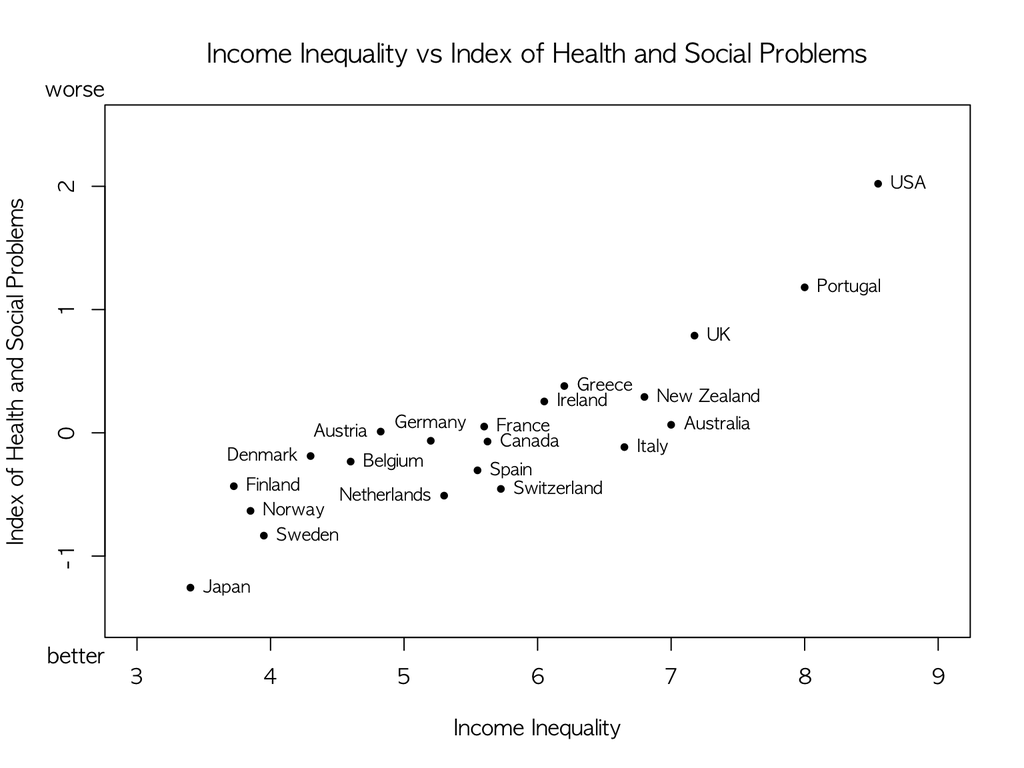

```r
plot(Index.of.health...social_problems~Income.inequality, data=data.1, pch=20, xlim=c(3, 9), ylim=c(-1.5, 2.5), ann=FALSE)
text(Income.inequality[text.right], Index.of.health...social_problems[text.right], labels=Country[text.right], pos=4, cex=0.8)
text(Income.inequality[text.left], Index.of.health...social_problems[text.left], labels=Country[text.left], pos=2, cex=0.8)
text(Income.inequality[text.up], Index.of.health...social_problems[text.up], labels=Country[text.up], pos=3, cex=0.8)
title(main="Income Inequality vs Index of Health and Social Problems", xlab="Income Inequality", ylab="Index of Health and Social Problems")
mtext("worse", side=2, at=2.8, las=1)
mtext("better", side=2, at=-1.8, las=1)
```

## 한글화 작업

국가명을 한글로 만들어 `Country.kr`로 저장하자.

```r
Country.kr<-c("호주", "오스트리아", "벨기에", "캐나다", "덴마크",
"핀란드", "프랑스", "독일", "그리스", "아일랜드", "이탈리아",
"일본", "네덜란드", "뉴질랜드", "노르웨이", "포르투갈",
"스페인", "스웨덴", "스위스", "영국", "미국")
```

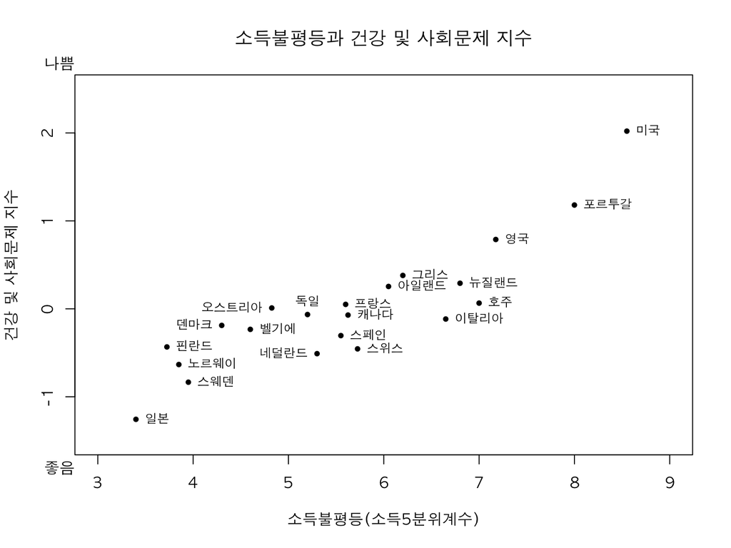

```r
plot(Index.of.health...social_problems~Income.inequality, data=data.1, pch=20, xlim=c(3, 9), ylim=c(-1.5, 2.5), ann=FALSE)
text(Income.inequality[text.right], Index.of.health...social_problems[text.right], labels=Country.kr[text.right], pos=4, cex=0.8)
text(Income.inequality[text.left], Index.of.health...social_problems[text.left], labels=Country.kr[text.left], pos=2, cex=0.8)
text(Income.inequality[text.up], Index.of.health...social_problems[text.up], labels=Country.kr[text.up], pos=3, cex=0.8)
title(main="소득불평등과 건강 및 사회문제 지수", xlab="소득불평등(소득5분위계수)", ylab="건강 및 사회문제 지수")
mtext("나쁨", side=2, at=2.8, las=1)
mtext("좋음", side=2, at=-1.8, las=1)
```

끝으로 두 변수 간의 상관계수 r = 0.87 를 도표 안에 표시하려면, 좌표를 잡아서

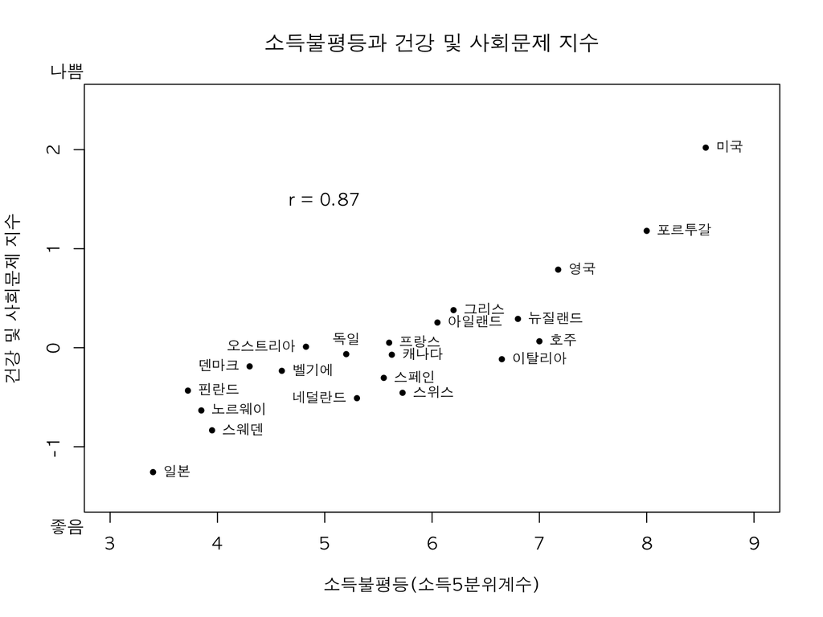

```r
plot(Index.of.health...social_problems~Income.inequality, data=data.1, pch=20, xlim=c(3, 9), ylim=c(-1.5, 2.5), ann=FALSE)
text(Income.inequality[text.right], Index.of.health...social_problems[text.right], labels=Country.kr[text.right], pos=4, cex=0.8)
text(Income.inequality[text.left], Index.of.health...social_problems[text.left], labels=Country.kr[text.left], pos=2, cex=0.8)
text(Income.inequality[text.up], Index.of.health...social_problems[text.up], labels=Country.kr[text.up], pos=3, cex=0.8)
text(x=5, y=1.5, labels=paste("r =", round(cor(data.1[,2], data.1[,3]), digits=2)))
title(main="소득불평등과 건강 및 사회문제 지수", xlab="소득불평등(소득5분위계수)", ylab="건강 및 사회문제 지수")
mtext("나쁨", side=2, at=2.8, las=1)
mtext("좋음", side=2, at=-1.8, las=1)
```